# A Model of Typical Weekday Sleeping Hours using Depression, Sex, and Race

- Show All Code
- Hide All Code
- View Source

Using data from 4870 adults in NHANES 2021-2023

Author

Lauren Sapienza

Modified

2025-12-10

# 1 Setup and Data Ingest

```r
library(janitor)
library(naniar)
library(xfun)
library(knitr)
library(patchwork)
library(nhanesA)
library(mice)
library(gt)
library(GGally)
library(car)
library(olsrr)
library(broom)
library(easystats)
library(tidyverse)
source("data/Love-431.R")

theme_set(theme_bw())
knitr::opts_chunk$set(comment = NA)
```

```r
# demo_raw <- nhanes('DEMO_L') |> tibble()
# saveRDS(demo_raw, "DEMO_L.Rds")

# depr_raw <- nhanes('DPQ_L') |> tibble()
# saveRDS(depr_raw, "DPQ_L.Rds")

# sleep_raw <- nhanes('SLQ_L')
# saveRDS(sleep_raw, "SLQ_L.Rds")

# smoke_raw <- nhanes('SMQ_L') |> tibble()
# saveRDS(smoke_raw, "SMQ_L.Rds")

# alc_raw <- nhanes('ALQ_L') |> tibble()
# saveRDS(alc_raw, "ALQ_L.Rds")

# bmi_raw <- nhanes('BMX_L') |> tibble()
# saveRDS(bmi_raw, "BMX_L.Rds")
```

Here we load in all our different data files using the `nhanesA` package, and save them as .Rds files, then comment the code out so we do not have to reload the data each time we run the code.

# 2 Cleaning the Data

## 2.1 Variable Cleaning and Renaming

```r
demo_raw <- readRDS('data/DEMO_L.Rds')

demo_raw <- demo_raw |>
  mutate(sex = factor(RIAGENDR),
         age = RIDAGEYR,
         race = fct_recode(factor(RIDRETH3),
                           "Hispanic" = "Mexican American",
                           "Hispanic" = "Other Hispanic",
                           "Other" = "Other Race - Including Multi-Racial"),
         check = factor(RIDSTATR)) |>
  select(SEQN, sex, age, race, check)
```

For the demographics data, we rename some of the variables for clarity, change the necessary variables into factors, and select only the variables we need. We also collapse ‘Mexican American’ and ‘Other Hispanic’ into one category called ‘Hispanic’ for the `race` variable.

```r
depr_raw <- readRDS('data/DPQ_L.Rds')

depr_raw <- depr_raw |> mutate(depr = factor(DPQ020)) |> select(SEQN, depr) |>
  replace_with_na_at(.vars = 'depr', condition = ~ .x == 'Refused') |>
  replace_with_na_at(.vars = 'depr', condition = ~ .x == "Don't know")
```

For the depression questionnaire data, we select our variable of interest, rename it for clarity, change it into a factor, and change all missing answers into NA values.

```r
sleep_raw <- readRDS('data/SLQ_L.Rds')

sleep_raw <- sleep_raw |> mutate(sleep = SLD012) |> select(SEQN, sleep)
```

For the sleep questionnaire data, we select our variable of interest and rename it for clarity.

```r
smoke_raw <- readRDS('data/SMQ_L.Rds')

smoke_raw <- smoke_raw |>
  mutate(smoke = case_when(SMQ040 == 'Every day' | SMQ040 == 'Some days' ~ "Smoker",
                           SMQ040 == 'Not at all' ~ "Non-Smoker")) |>
  mutate(smoke = factor(smoke)) |> select(SEQN, smoke)
```

For the smoking questionnaire data, we select our variable of interest, rename it for clarity, and change it into a factor. We also collapse the answers of ‘every day’ and ‘some days’ into a category called ‘smoker’.

```r
alc_raw <- readRDS('data/ALQ_L.Rds')

alc_raw <- alc_raw |> mutate(alcohol = factor(ALQ151)) |> select(SEQN, alcohol)|>
  replace_with_na_at(.vars = 'alcohol', condition = ~ .x == 'Refused') |>
  replace_with_na_at(.vars = 'alcohol', condition = ~ .x == "Don't know")
```

For the alcohol questionnaire data, we select our variable of interest, rename it for clarity, change it into a factor, and change all missing answers into NA values.

```r
bmi_raw <- readRDS('data/BMX_L.Rds')

bmi_raw <- bmi_raw |> mutate(bmi = BMXBMI) |> select(SEQN, bmi)
```

For the BMI examination data, we select our variable of interest and rename it for clarity.

```r
NEW <- left_join(demo_raw, depr_raw, by = "SEQN")
NEW2 <- left_join(NEW, alc_raw, by = "SEQN")
NEW3 <- left_join(NEW2, smoke_raw, by = "SEQN")
NEW4 <- left_join(NEW3, sleep_raw, by = "SEQN")
study2_raw <- left_join(NEW4, bmi_raw, by = "SEQN")

study2_raw <- study2_raw |>
  filter(age < 80 & age >= 21 & check == 'Both interviewed and MEC examined') |>
  filter(sleep <= 13.5 & sleep >= 3 & check == 'Both interviewed and MEC examined') |>
  mutate(seqn = as.character(SEQN)) |>
  mutate(race = fct_relevel(race, 'Non-Hispanic White')) |>
  mutate(alcohol = fct_relevel(alcohol, 'No')) |>
  mutate(sex = fct_relevel(sex, 'Female')) |>
  select(seqn, age, sex, race, depr, alcohol, smoke, bmi, sleep, check) |>
  droplevels()
```

We then join all of our tibbles by `SEQN`, and filter our data to only adults between 21 and 79 that were both interviewed and MEC examined. We also change `seqn` into a character variable and reorder the columns of our tibble. We also filter the `sleep` variable to values only between 3 and 13.5, as the value of 2 represents 3 hours and below and the value of 14 represents 14 hours and above respectively.

## 2.2 Missing Data

```r
miss_var_summary(study2_raw) |>
  gt() |> fmt_number(decimals = 4, drop_trailing_zeros = TRUE)
```

| variable | n_miss | pct_miss |
| --- | --- | --- |
| smoke | 3,285 | 59.0 |
| alcohol | 1,124 | 20.2 |
| depr | 694 | 12.5 |
| bmi | 72 | 1.29 |
| seqn | 0 | 0 |
| age | 0 | 0 |
| sex | 0 | 0 |
| race | 0 | 0 |
| sleep | 0 | 0 |
| check | 0 | 0 |

```r
miss_case_table(study2_raw) |>
  gt() |> fmt_number(decimals = 4, drop_trailing_zeros = TRUE)
```

| n_miss_in_case | n_cases | pct_cases |
| --- | --- | --- |
| 0 | 1,872 | 33.6449 |
| 1 | 2,657 | 47.7534 |
| 2 | 612 | 10.9993 |
| 3 | 398 | 7.1531 |
| 4 | 25 | 0.4493 |

We are missing quite a bit of data, with only 33.6% of cases having complete data. As expected, however, all subjects have data for `seqn`, `age`, and `check` since we used these variables to filter the data. It looks like most of our subjects are only missing data in 2 or less variables. For study 2, we are assuming our outcome and key predictor data are missing at random and we filter to complete cases of just these variables.

```r
study2_raw <- study2_raw |> filter(complete.cases(seqn, depr, sleep))

summary(study2_raw)
```

```
     seqn                age            sex                       race
 Length:4870        Min.   :21.00   Female:2669   Non-Hispanic White:2967
 Class :character   1st Qu.:39.00   Male  :2201   Hispanic          : 793
 Mode  :character   Median :56.00                 Non-Hispanic Black: 573
                    Mean   :52.73                 Non-Hispanic Asian: 221
                    3rd Qu.:66.00                 Other             : 316
                    Max.   :79.00

                      depr      alcohol            smoke           bmi
 Not at all             :3282   No  :3598   Non-Smoker:1260   Min.   :11.10
 Several days           :1156   Yes : 838   Smoker    : 736   1st Qu.:24.80
 More than half the days: 252   NA's: 434   NA's      :2874   Median :28.60
 Nearly every day       : 180                                 Mean   :29.92
                                                              3rd Qu.:33.70
                                                              Max.   :69.90
                                                              NA's   :40
     sleep                                      check
 Min.   : 3.000   Both interviewed and MEC examined:4870
 1st Qu.: 7.000
 Median : 8.000
 Mean   : 7.655
 3rd Qu.: 8.500
 Max.   :13.500
```

A quick summary of the data shows us that all our variables look as acceptable at this stage and shows us our final data set contains 4870 subjects.

## 2.3 Single Imputation

We now perform our single imputation, assuming that all our variables are missing at random.

```r
set.seed(431)

# study2_mice <- mice(study2_raw, m = 1, printFlag = FALSE)
# study2_imp <- complete(study2_mice, 1) |> tibble()

# saveRDS(study2_imp, "data/study2.Rds")

study2 <- readRDS("data/study2.Rds")

n_miss(study2)
```

```
[1] 0
```

After our single imputation, we no longer have any missing data. We save our final tibble to a .Rds file and then we check to make sure we have enough subjects for our analysis.

## 2.4 Checking Variables

```r
study2 |> select(sleep) |> n_distinct()
```

```
[1] 22
```

```r
study2 |> select(bmi) |> n_distinct()
```

```
[1] 398
```

```r
study2 |> select(age) |> n_distinct()
```

```
[1] 59
```

For each of our quantitative predictors and our outcome, we have over 15 unique values in each group.

```r
summary(study2 |> select(depr, sex, race, alcohol, smoke))
```

```
                      depr          sex                       race
 Not at all             :3282   Female:2669   Non-Hispanic White:2967
 Several days           :1156   Male  :2201   Hispanic          : 793
 More than half the days: 252                 Non-Hispanic Black: 573
 Nearly every day       : 180                 Non-Hispanic Asian: 221
                                              Other             : 316
 alcohol           smoke
 No :3954   Non-Smoker:3072
 Yes: 916   Smoker    :1798
```

For each of our categorical predictors, we have over 30 observations in each group.

# 3 Codebook and Data Description

Our final data set contains 4870 adults that participated in NHANES 2021-2023 between ages 21 and 79 who have complete data on the `depr` and `sleep` variables and were both interviewed and MEC examined.

## 3.1 Codebook

| Variable | Type | Description | Old Name |
| --- | --- | --- | --- |
| **seqn** | ID | Respondent sequence number | `SEQN` |
| **age** | Quant | Age in years at screening, 21 to 79 | `RIDAGEYR` |
| **sex** | Binary | Female, Male: Gender of the participant | `RIAGENDR` |
| **race** | 5-Cat | Non-Hispanic White, Hispanic, Non-Hispanic Black, Non-Hispanic Asian, Other: Reported race and Hispanic origin information | `RIDRETH3` |
| **depr** | 4-Cat | **Key Predictor:** Not at all, Several days, More than half the days, Nearly every day: Over the last 2 weeks, how often have you been bothered by the following problem: feeling down, depressed, or ho… | `DPQ020` |
| **alcohol** | Binary | No, Yes: Was there ever a time or times in your life when you drank 4/5 or more drinks of any kind of alcoholic beverage almost every day? | `ALQ151` |
| **smoke** | Binary | Non-Smoker, Smoker: Do you now smoke cigarettes? | `SMQ040` |
| **bmi** | Quant | Body Mass Index (kg/m<sup>2</sup>) | `BMXBMI` |
| **sleep** | Quant | **Outcome:** Number of hours usually sleep on weekdays or workdays | `SLD012` |
| **check** | check | Interview and examination status of the participant, should be ‘both interviewed and MEC examined’ for all subjects | `RIDSTATR` |

## 3.2 Analytic Tibble

```r
study2
```

```
# A tibble: 4,870 × 10
   seqn     age sex    race               depr   alcohol smoke   bmi sleep check
   <chr>  <dbl> <fct>  <fct>              <fct>  <fct>   <fct> <dbl> <dbl> <fct>
 1 130379    66 Male   Non-Hispanic White Not a… No      Non-…  33.5   9   Both…
 2 130380    44 Female Hispanic           Not a… No      Smok…  29.7   8   Both…
 3 130386    34 Male   Hispanic           Not a… No      Non-…  30.2   7.5 Both…
 4 130387    68 Female Non-Hispanic White Not a… No      Non-…  42.6   3   Both…
 5 130389    59 Male   Non-Hispanic White Not a… No      Non-…  28     8   Both…
 6 130391    33 Female Non-Hispanic White Nearl… No      Smok…  38.9   7.5 Both…
 7 130392    74 Female Non-Hispanic White Not a… No      Non-…  43     9   Both…
 8 130393    39 Male   Non-Hispanic White Not a… No      Non-…  46.1   7   Both…
 9 130394    51 Male   Non-Hispanic White Not a… No      Non-…  24.4   8   Both…
10 130395    33 Female Other              Sever… No      Non-…  54.6   7.5 Both…
# ℹ 4,860 more rows
```

## 3.3 Data Summary

```r
data_codebook(study2 |> select(-seqn))
```

```
select(study2, -seqn) (4870 rows and 9 variables, 9 shown)

ID | Name    | Type        | Missings |                            Values |             N
---+---------+-------------+----------+-----------------------------------+--------------
1  | age     | numeric     | 0 (0.0%) |                          [21, 79] |          4870
---+---------+-------------+----------+-----------------------------------+--------------
2  | sex     | categorical | 0 (0.0%) |                            Female | 2669 ( 54.8%)
   |         |             |          |                              Male | 2201 ( 45.2%)
---+---------+-------------+----------+-----------------------------------+--------------
3  | race    | categorical | 0 (0.0%) |                Non-Hispanic White | 2967 ( 60.9%)
   |         |             |          |                          Hispanic |  793 ( 16.3%)
   |         |             |          |                Non-Hispanic Black |  573 ( 11.8%)
   |         |             |          |                Non-Hispanic Asian |  221 (  4.5%)
   |         |             |          |                             Other |  316 (  6.5%)
---+---------+-------------+----------+-----------------------------------+--------------
4  | depr    | categorical | 0 (0.0%) |                        Not at all | 3282 ( 67.4%)
   |         |             |          |                      Several days | 1156 ( 23.7%)
   |         |             |          |           More than half the days |  252 (  5.2%)
   |         |             |          |                  Nearly every day |  180 (  3.7%)
---+---------+-------------+----------+-----------------------------------+--------------
5  | alcohol | categorical | 0 (0.0%) |                                No | 3954 ( 81.2%)
   |         |             |          |                               Yes |  916 ( 18.8%)
---+---------+-------------+----------+-----------------------------------+--------------
6  | smoke   | categorical | 0 (0.0%) |                        Non-Smoker | 3072 ( 63.1%)
   |         |             |          |                            Smoker | 1798 ( 36.9%)
---+---------+-------------+----------+-----------------------------------+--------------
7  | bmi     | numeric     | 0 (0.0%) |                      [11.1, 69.9] |          4870
---+---------+-------------+----------+-----------------------------------+--------------
8  | sleep   | numeric     | 0 (0.0%) |                         [3, 13.5] |          4870
---+---------+-------------+----------+-----------------------------------+--------------
9  | check   | categorical | 0 (0.0%) | Both interviewed and MEC examined | 4870 (100.0%)
-----------------------------------------------------------------------------------------
```

All our variables appear as expected, with reasonable ranges of values and no missing values.

# 4 Research Question

For this study, I was interested in looking at the connections between sleep and depression, considering that being overly tired or overly restless are symptoms of depression that are asked about on the PHQ-9, the depression screening used in NHANES. As such, I was curious if using a depression screening question would be enough to effectively predict how many hours a person usually sleeps on a weeknight. I believe that the more days reported feeling ‘feeling down, depressed, or hopeless’, they will sleep more on average. My research question is:

How effectively can we predict the average hours spent sleeping on weeknights using the answers to the depression screening question ‘feeling down, depressed, or hopeless’ along with other predictors including age, sex, race, alcohol abuse history, smoker status and BMI and does a simpler model created using best subsets meaningfully effect the quality of prediction?

# 5 Partitioning the Data

```r
c(nrow(study2), n_distinct(study2$seqn))
```

```
[1] 4870 4870
```

First, we check that our subject numbers are unique to each row of our analytic data, which they are. We can now continue to dividing the data, putting 70% of the data in the training sample (`study2_train`) leaving the other 30% for the test sample (`study2_test`)

```r
set.seed(4312)

study2_train <- study2 |> slice_sample(prop = 0.7, replace = FALSE)
study2_test <- anti_join(study2, study2_train, by = "seqn")

c(nrow(study2_train) + nrow(study2_test), n_distinct(study2))
```

```
[1] 4870 4870
```

We quickly check that the sum of the subjects in the testing and training groups are equal to the number of subjects in our original data set, which is true.

# 6 Transforming the Outcome

## 6.1 Numerical Summaries

```r
study2_train |> reframe(lovedist(sleep)) |>
  gt() |> fmt_number(decimals = 2, drop_trailing_zeros = TRUE)
```

| n | miss | mean | sd | med | mad | min | q25 | q75 | max |
| --- | --- | --- | --- | --- | --- | --- | --- | --- | --- |
| 3,409 | 0 | 7.67 | 1.46 | 8 | 1.48 | 3 | 7 | 8.5 | 13.5 |

It looks like the distribution of our outcome is fairly symmetric, but we might have some outliers considering the range is much greater than the interquartile range.

```r
describe_distribution(study2_train |> select(-sleep)) |>
  gt() |> fmt_number(decimals = 2, drop_trailing_zeros = TRUE)
```

| Variable | Mean | SD | IQR | Min | Max | Skewness | Kurtosis | n | n_Missing |
| --- | --- | --- | --- | --- | --- | --- | --- | --- | --- |
| age | 52.51 | 16.25 | 28 | 21 | 79 | −0.3 | −1.15 | 3,409 | 0 |
| bmi | 29.86 | 7.29 | 8.75 | 14.9 | 69.9 | 1.2 | 2.37 | 3,409 | 0 |

```r
summary(study2_train |> select(depr, sex, race, alcohol, smoke))
```

```
                      depr          sex                       race
 Not at all             :2273   Female:1870   Non-Hispanic White:2078
 Several days           : 825   Male  :1539   Hispanic          : 565
 More than half the days: 189                 Non-Hispanic Black: 389
 Nearly every day       : 122                 Non-Hispanic Asian: 163
                                              Other             : 214
 alcohol           smoke
 No :2767   Non-Smoker:2127
 Yes: 642   Smoker    :1282
```

Everything looks good for our predictors as well.

## 6.2 Visual Summaries

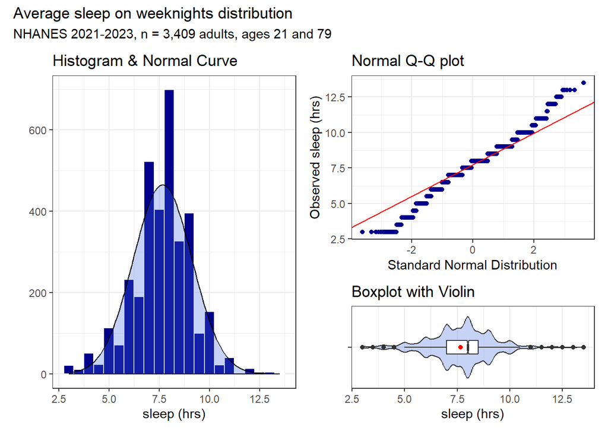

```r
p1 <- ggplot(study2_train, aes(x = sleep)) +
  geom_histogram(binwidth = 0.5,
                 fill = "darkblue", col = "white") +
  stat_function(fun = function(x)
    dnorm(x, mean = mean(study2_train$sleep, na.rm = TRUE),
          sd = sd(study2_train$sleep, na.rm = TRUE)) *
      length(study2_train$sleep) * 0.5,
    geom = "area", alpha = 0.3,
    fill = "royalblue", col = "black") +
  labs(x = "sleep (hrs)", y = "",
       title = "Histogram & Normal Curve")

p2 <- ggplot(study2_train, aes(sample = (sleep))) +
  geom_qq(col = "darkblue") +
  geom_qq_line(col = "red") +
  labs(y = "Observed sleep (hrs)",
       x = "Standard Normal Distribution",
       title = 'Normal Q-Q plot')

p3 <- ggplot(study2_train, aes(x = sleep, y = "")) +
  geom_violin(fill = "royalblue", alpha = 0.3) +
  geom_boxplot(width = 0.2, notch = TRUE) +
  stat_summary(fun = mean, geom = "point", shape = 16, col = "red") +
  labs(y = "", x = "sleep (hrs)",
       title = "Boxplot with Violin")

p1 + (p2 / p3 + plot_layout(heights = c(2, 1))) +
  plot_annotation(title = "Average sleep on weeknights distribution",
                  subtitle = 'NHANES 2021-2023, n = 3,409 adults, ages 21 and 79')
```

It looks like our distribution is a little heavy tailed, but symmetric, with a good amount of outliers. It does not seem like it will benefit from a transformation because of this, but we will see if it is of any help in a moment. We also get some pretty interesting shaped graphs, which I believe is due to the majority of answers to `sleep` being on the hour, followed by the half hour.

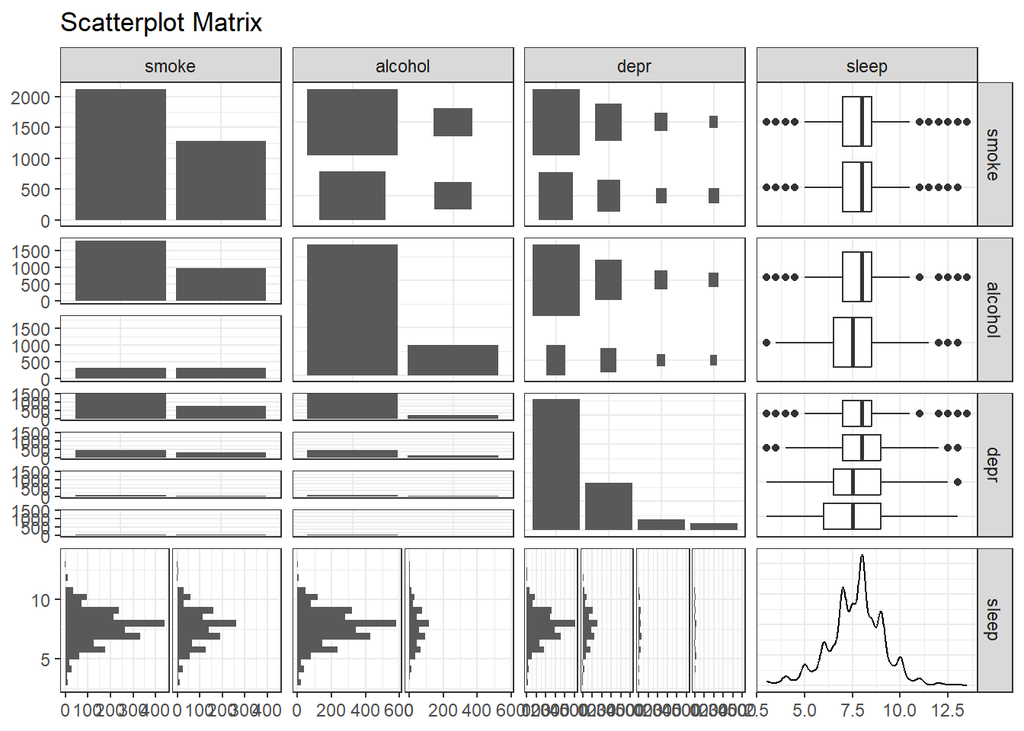

```r
corr_temp1 <- study2_train |>
  select(smoke, alcohol, depr, sleep)

corr_temp2 <- study2_train |>
  select(race, sex, age, bmi, sleep)


ggpairs(corr_temp1, title = "Scatterplot Matrix",
        lower = list(combo = wrap("facethist", bins = 20)))
```

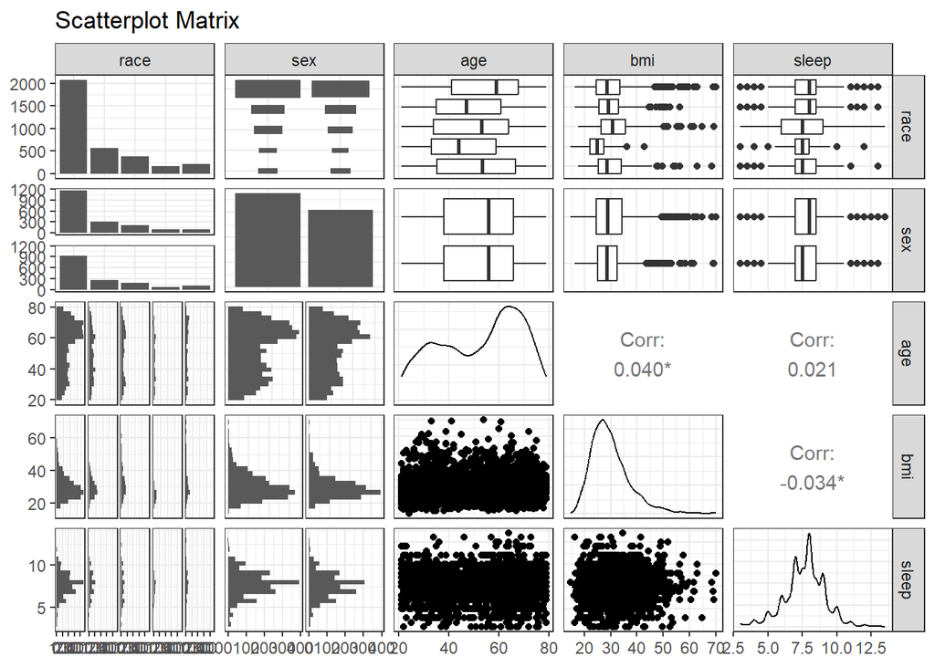

```r
ggpairs(corr_temp2, title = "Scatterplot Matrix",
        lower = list(combo = wrap("facethist", bins = 20)))
```

There is a lot here, so we will focus on checking for collinearity between our predictors and comparing our key predictor to our outcome. First, it does not currently seem like we have any collinearity issues, as our largest Pearson correlation between predictors is only 0.040. However, it is not very promising that we do not have that high of Pearson correlation between our predictors and our outcome either. Looking at the relationship between `sleep` and `depr`, it seems like something might be going on in the box plots, as there are less outliers as the categories change, but I think that might just be from the sample size decreasing as the categories change.

```r
study2_train |> group_by(depr)|> reframe(lovedist(sleep)) |>
  gt() |> fmt_number(decimals = 2, drop_trailing_zeros = TRUE)
```

| depr | n | miss | mean | sd | med | mad | min | q25 | q75 | max |
| --- | --- | --- | --- | --- | --- | --- | --- | --- | --- | --- |
| Not at all | 2,273 | 0 | 7.69 | 1.33 | 8 | 1.48 | 3 | 7 | 8.5 | 13.5 |
| Several days | 825 | 0 | 7.68 | 1.57 | 8 | 1.48 | 3 | 7 | 9 | 13 |
| More than half the days | 189 | 0 | 7.59 | 1.89 | 7.5 | 2.22 | 3 | 6.5 | 9 | 13 |
| Nearly every day | 122 | 0 | 7.35 | 2.15 | 7.5 | 2.22 | 3 | 6 | 9 | 13 |

Looking at the distribution by `depr` answer seems to confirm this, as all groups have similar ranges, but since the last two groups have far less subjects than the other two, they have larger standard deviations that make less values appear as outliers.

## 6.3 Transformation

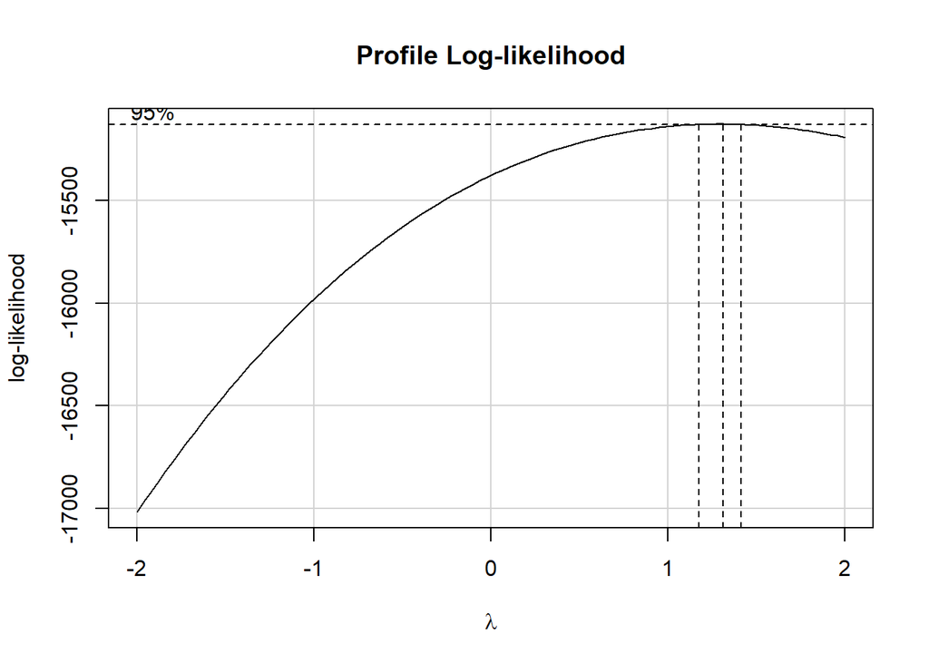

```r
model_temp <- lm(sleep ~ depr + age + sex + race + alcohol + smoke + bmi,
                 data = study2_train)

boxCox(model_temp)
```

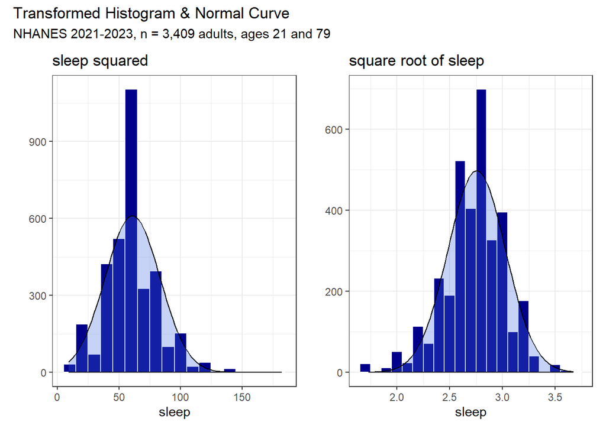

```r
study2_trans <- study2_train |> mutate(sleep2 = sleep**2,
                                       sleepsqrt = sqrt(sleep))

p4 <- ggplot(study2_trans, aes(x = (sleep2))) +
  geom_histogram(binwidth = 10,
                 fill = "darkblue", col = "white") +
  stat_function(fun = function(x)
    dnorm(x, mean = mean(study2_trans$sleep2, na.rm = TRUE),
          sd = sd(study2_trans$sleep2, na.rm = TRUE)) *
      length(study2_trans$sleep2) * 10,
    geom = "area", alpha = 0.3,
    fill = "royalblue", col = "black") +
  labs(x = "sleep", y = "",
       title = "sleep squared")

p5 <- ggplot(study2_trans, aes(x = sleepsqrt)) +
  geom_histogram(binwidth = 0.1,
                 fill = "darkblue", col = "white") +
  stat_function(fun = function(x)
    dnorm(x, mean = mean(study2_trans$sleepsqrt, na.rm = TRUE),
          sd = sd(study2_trans$sleepsqrt, na.rm = TRUE)) *
      length(study2_trans$sleepsqrt) * 0.1,
    geom = "area", alpha = 0.3,
    fill = "royalblue", col = "black") +
  labs(x = "sleep", y = "",
       title = "square root of sleep")

p4 + p5 +
  plot_annotation(title = "Transformed Histogram & Normal Curve",
                  subtitle = 'NHANES 2021-2023, n = 3,409 adults, ages 21 and 79')
```

Neither of these transformations seem any better than our original, and our analysis will be a little easier to interpret without transforming, so we will not transform our outcome.

# 7 The Big Model

```r
big_model <- lm(sleep ~ depr + age + sex + race + alcohol + smoke + bmi,
                data = study2_train)

model_performance(big_model)
```

```
# Indices of model performance

AIC     |    AICc |     BIC |    R2 | R2 (adj.) |  RMSE | Sigma
---------------------------------------------------------------
12249.4 | 12249.5 | 12335.3 | 0.012 |     0.008 | 1.453 | 1.456
```

```r
model_parameters(big_model, ci = 0.90) |>
  gt() |> fmt_number(decimals = 4, drop_trailing_zeros = TRUE)
```

| Parameter | Coefficient | SE | CI | CI_low | CI_high | t | df_error | p |
| --- | --- | --- | --- | --- | --- | --- | --- | --- |
| (Intercept) | 8.0206 | 0.1481 | 0.9 | 7.7769 | 8.2642 | 54.167 | 3,396 | 0 |
| deprSeveral days | −0.0046 | 0.0607 | 0.9 | −0.1046 | 0.0953 | −0.0764 | 3,396 | 0.9391 |
| deprMore than half the days | −0.0696 | 0.1115 | 0.9 | −0.2531 | 0.1139 | −0.6237 | 3,396 | 0.5329 |
| deprNearly every day | −0.3159 | 0.1371 | 0.9 | −0.5415 | −0.0903 | −2.3039 | 3,396 | 0.0213 |
| age | 0.0009 | 0.0016 | 0.9 | −0.0018 | 0.0035 | 0.5453 | 3,396 | 0.5856 |
| sexMale | −0.1843 | 0.0506 | 0.9 | −0.2676 | −0.101 | −3.6395 | 3,396 | 0.0003 |
| raceHispanic | −0.0501 | 0.0699 | 0.9 | −0.1651 | 0.065 | −0.716 | 3,396 | 0.474 |
| raceNon-Hispanic Black | −0.2001 | 0.0827 | 0.9 | −0.3363 | −0.064 | −2.4188 | 3,396 | 0.0156 |
| raceNon-Hispanic Asian | −0.3596 | 0.1205 | 0.9 | −0.5578 | −0.1614 | −2.9848 | 3,396 | 0.0029 |
| raceOther | −0.1306 | 0.1051 | 0.9 | −0.3036 | 0.0423 | −1.2426 | 3,396 | 0.2141 |
| alcoholYes | −0.0248 | 0.0656 | 0.9 | −0.1326 | 0.0831 | −0.3779 | 3,396 | 0.7055 |
| smokeSmoker | −0.0248 | 0.0544 | 0.9 | −0.1142 | 0.0646 | −0.4563 | 3,396 | 0.6482 |
| bmi | −0.0077 | 0.0035 | 0.9 | −0.0134 | −0.0019 | −2.1842 | 3,396 | 0.029 |

## 7.1 Describing the Equation

This model implies for the key predictor, `depr`, that:

- Point Estimate: If we had two subjects with the same values of `age`, `sex`, `race`, `alcohol`, `smoke`, and `bmi`, and one subject had a `depr` value of ‘not at all’ and the other subject had `depr` value of ‘several days’, our model predicts that the subject that answered ‘several days’ will have a `sleep` value 0.0046 hours (90% CI: −0.10, 0.10) less than the other.
- 90% Confidence Interval: Our `big_model` estimates the coefficient of `depr` = ‘several days’ to be -0.0046 hours in the participants in our study. When we generalize beyond study participants to the population they were selected at random from, then our data are compatible (at the 90% confidence level) with values between -0.10 and 0.10 hours for `sleep`.
- Point Estimate: If we had two subjects with the same values of all other variables, and one subject had a `depr` value of ‘not at all’ and the other subject had `depr` value of ‘more than half the days’, our model predicts that the subject that answered ‘more than half the days’ will have a `sleep` value 0.070 hours (90% CI: −0.25, 0.11) less than the other.
- 90% Confidence Interval: Our `big_model` estimates the coefficient of `depr` = ‘more than half the days’ to be -0.070 hours in the participants in our study. When we generalize beyond study participants to the population they were selected at random from, then our data are compatible (at the 90% confidence level) with values between −0.25 and 0.11 hours for `sleep`.
- Point Estimate: If we had two subjects with the same values of all other variables, and one subject had a `depr` value of ‘not at all’ and the other subject had `depr` value of ‘nearly every day’, our model predicts that the subject that answered ‘nearly every day’ will have a `sleep` value 0.32 hours (90% CI: -0.54, -0.09) less than the other.
- 90% Confidence Interval: Our `big_model` estimates the coefficient of `depr` = ‘nearly every day’ to be -0.32 hours in the participants in our study. When we generalize beyond study participants to the population they were selected at random from, then our data are compatible (at the 90% confidence level) with values between -0.54 and -0.09 hours for `sleep`.

We can also interpret the y-intercept as:

- If a subject had:
  - `depr` = Not at all
  - `age` = 0
  - `sex` = Female
  - `race` = Non-Hispanic White
  - `alcohol` = No
  - `smoke` = Non-Smoker
  - `bmi` = 0
- Their `sleep` value would be estimated by our model to be 8.02 hours. However, 0 is outside of the range of our data for `age` and `bmi`, so this value has little meaning for us on its own.

# 8 The Smaller Model

```r
ols_step_best_subset(big_model, max_order = 3, metric = "cp")
```

```
  Best Subsets Regression
---------------------------
Model Index    Predictors
---------------------------
     1         sex
     2         sex race
     3         sex race bmi
---------------------------

                                                      Subsets Regression Summary
---------------------------------------------------------------------------------------------------------------------------------------
                       Adj.        Pred
Model    R-Square    R-Square    R-Square     C(p)         AIC          SBIC          SBC          MSEP        FPE       HSP      APC
---------------------------------------------------------------------------------------------------------------------------------------
  1        0.0040      0.0037      0.0028    18.1622    12254.5640    2580.2245    12272.9665    7258.2350    2.1304    6e-04    0.9972
  2        0.0083      0.0069      0.0044    11.1436    12247.5746    2567.2532    12290.5138    7228.5130    2.1242    6e-04    0.9934
  3        0.0098      0.0080      0.0051     8.1270    12244.5530    2564.2439    12293.6264    7219.9933    2.1223    6e-04    0.9925
---------------------------------------------------------------------------------------------------------------------------------------
AIC: Akaike Information Criteria
 SBIC: Sawa's Bayesian Information Criteria
 SBC: Schwarz Bayesian Criteria
 MSEP: Estimated error of prediction, assuming multivariate normality
 FPE: Final Prediction Error
 HSP: Hocking's Sp
 APC: Amemiya Prediction Criteria
```

I decided to use best subsets to generate a smaller model from our `big_model`, and found that my key predictor was not in any of the best small models. As such, I decided to add the model 2 variables with `depr` for my final model. There is a nice difference between the R<sup>2</sup> of models 1 and 2, but not as much of a jump between 2 and 3, so we will use `depr`, `sex`, and `race` as the variables in our small model.

```r
small_model <- lm(sleep ~ depr + sex + race,
                data = study2_train)

model_performance(small_model)
```

```
# Indices of model performance

AIC     |    AICc |     BIC |    R2 | R2 (adj.) |  RMSE | Sigma
---------------------------------------------------------------
12246.7 | 12246.8 | 12308.1 | 0.010 |     0.008 | 1.454 | 1.456
```

```r
model_parameters(small_model, ci = 0.90) |>
  gt() |> fmt_number(decimals = 4, drop_trailing_zeros = TRUE)
```

| Parameter | Coefficient | SE | CI | CI_low | CI_high | t | df_error | p |
| --- | --- | --- | --- | --- | --- | --- | --- | --- |
| (Intercept) | 7.8316 | 0.0429 | 0.9 | 7.761 | 7.9022 | 182.4831 | 3,400 | 0 |
| deprSeveral days | −0.0164 | 0.0594 | 0.9 | −0.1141 | 0.0813 | −0.2765 | 3,400 | 0.7822 |
| deprMore than half the days | −0.0848 | 0.1106 | 0.9 | −0.2667 | 0.0972 | −0.7664 | 3,400 | 0.4435 |
| deprNearly every day | −0.3446 | 0.1355 | 0.9 | −0.5676 | −0.1215 | −2.542 | 3,400 | 0.0111 |
| sexMale | −0.1821 | 0.0503 | 0.9 | −0.2648 | −0.0994 | −3.6233 | 3,400 | 0.0003 |
| raceHispanic | −0.0569 | 0.0692 | 0.9 | −0.1709 | 0.057 | −0.8221 | 3,400 | 0.4111 |
| raceNon-Hispanic Black | −0.2276 | 0.0805 | 0.9 | −0.3601 | −0.095 | −2.8251 | 3,400 | 0.0048 |
| raceNon-Hispanic Asian | −0.3319 | 0.1185 | 0.9 | −0.5268 | −0.1369 | −2.8007 | 3,400 | 0.0051 |
| raceOther | −0.1414 | 0.1048 | 0.9 | −0.3138 | 0.031 | −1.3497 | 3,400 | 0.1772 |

## 8.1 Describing the Equation

This model implies for the key predictor, `depr`, that:

- Point Estimate: If we had two subjects with the same values of `sex` and `race`, and one subject had a `depr` value of ‘not at all’ and the other subject had `depr` value of ‘several days’, our model predicts that the subject that answered ‘several days’ will have a `sleep` value 0.016 hours (90% CI: -0.11, 0.08) less than the other.
- 90% Confidence Interval: Our `small_model` estimates the coefficient of `depr` = ‘several days’ to be -0.016 hours in the participants in our study. When we generalize beyond study participants to the population they were selected at random from, then our data are compatible (at the 90% confidence level) with values between -0.11 and 0.08 hours for `sleep`.
- Point Estimate: If we had two subjects with the same values of all other variables, and one subject had a `depr` value of ‘not at all’ and the other subject had `depr` value of ‘more than half the days’, our model predicts that the subject that answered ‘more than half the days’ will have a `sleep` value 0.085 hours (90% CI: -0.27, 0.10) less than the other.
- 90% Confidence Interval: Our `small_model` estimates the coefficient of `depr` = ‘more than half the days’ to be -0.085 hours in the participants in our study. When we generalize beyond study participants to the population they were selected at random from, then our data are compatible (at the 90% confidence level) with values between -0.27 and 0.10 hours for `sleep`.
- Point Estimate: If we had two subjects with the same values of all other variables, and one subject had a `depr` value of ‘not at all’ and the other subject had `depr` value of ‘nearly every day’, our model predicts that the subject that answered ‘nearly every day’ will have a `sleep` value 0.34 hours (90% CI: -0.57, -0.12) less than the other.
- 90% Confidence Interval: Our `small_model` estimates the coefficient of `depr` = ‘nearly every day’ to be -0.34 hours in the participants in our study. When we generalize beyond study participants to the population they were selected at random from, then our data are compatible (at the 90% confidence level) with values between -0.57 and -0.12 hours for `sleep`.

We can also interpret the y-intercept as:

- If a subject had:
  - `depr` = Not at all
  - `sex` = Female
  - `race` = Non-Hispanic White
- Their `sleep` value would be estimated by our model to be 7.83 hours. In this case, this value is actually possible, and would be the estimate of the average weekday sleep hours for Non-Hispanic White women that answered ‘not at all’ to feeling down, depressed, or hopeless.

# 9 In-Sample Comparison

## 9.1 Quality of Fit

```r
compare_performance(big_model, small_model, rank = TRUE)
```

```
# Comparison of Model Performance Indices

Name        | Model |    R2 | R2 (adj.) |  RMSE | Sigma | AIC weights
---------------------------------------------------------------------
big_model   |    lm | 0.012 |     0.008 | 1.453 | 1.456 |       0.208
small_model |    lm | 0.010 |     0.008 | 1.454 | 1.456 |       0.792

Name        | AICc weights | BIC weights | Performance-Score
------------------------------------------------------------
big_model   |        0.203 |    1.23e-06 |            57.14%
small_model |        0.797 |       1.000 |            42.86%
```

It looks like the big model wins 2 measures, the small model wins 3 measures, and they are tied on 2, so things are still up in the air about which model is better. Admittedly, neither of them are that great at this stage, with R<sup>2</sup> of only 0.012 and 0.010.

## 9.2 Posterior Predictive Checks

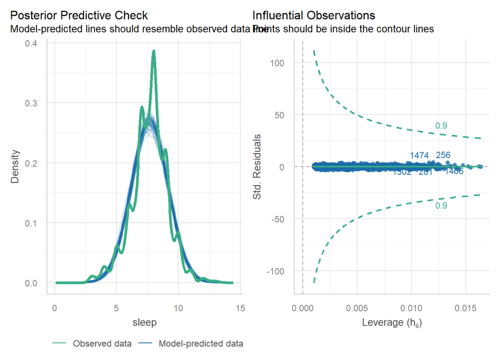

```r
check_model(big_model, check = c("pp_check", "outliers"))
```

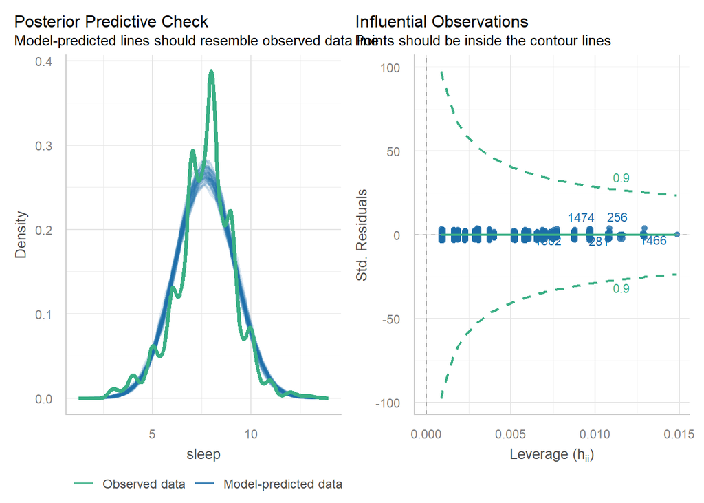

```r
check_model(small_model, check = c("pp_check", "outliers"))
```

It is hard to tell how well fit the posterior predictive check is to our data, considering the hills and valleys created by having answers to `sleep` on the hour and half hour, but our data is much higher at the peak that the modeled lines. It looks like we don’t have any influential observations for either model as well.

## 9.3 Assessing Assumptions

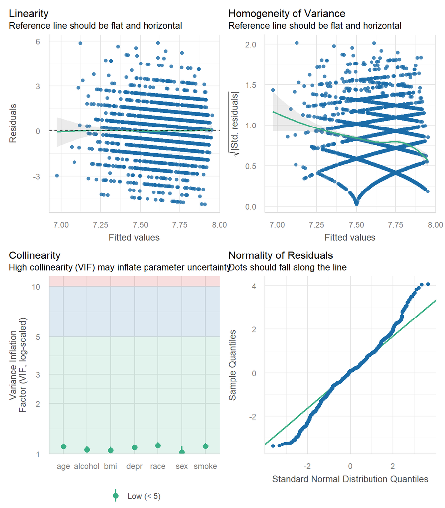

```r
check_model(big_model, detrend = FALSE, check = c("linearity", "homogeneity", "vif", "qq"))
```

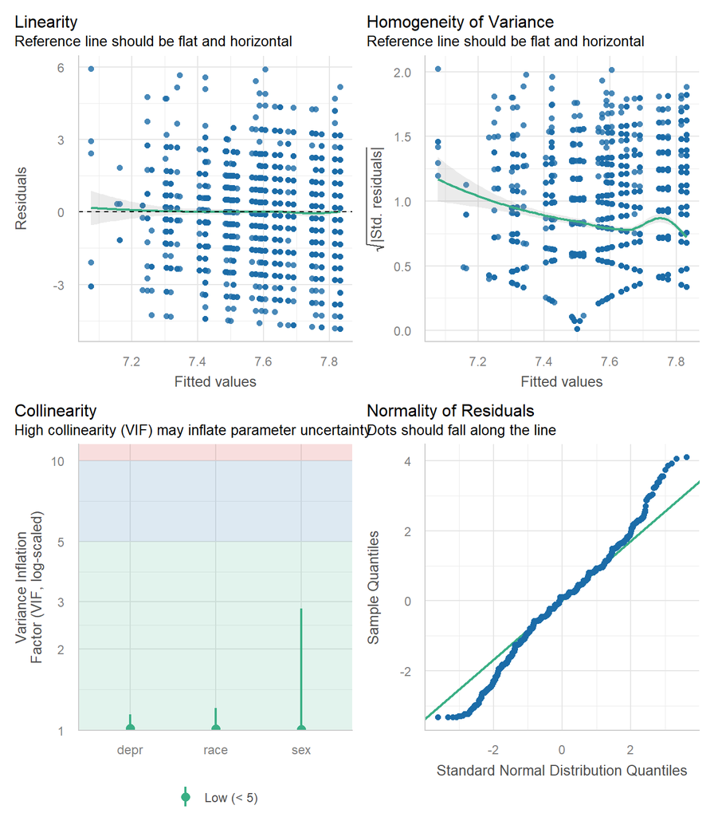

```r
check_model(small_model, detrend = FALSE, check = c("linearity", "homogeneity", "vif", "qq"))
```

The `check_model` graphs here look pretty similar for each model. There does not appear to be any concerns about linearity or collinearity. Homogeneity of variance looks more concerning , but not terrible, and as expected there are still issues with normality.

## 9.4 Comparing the Models

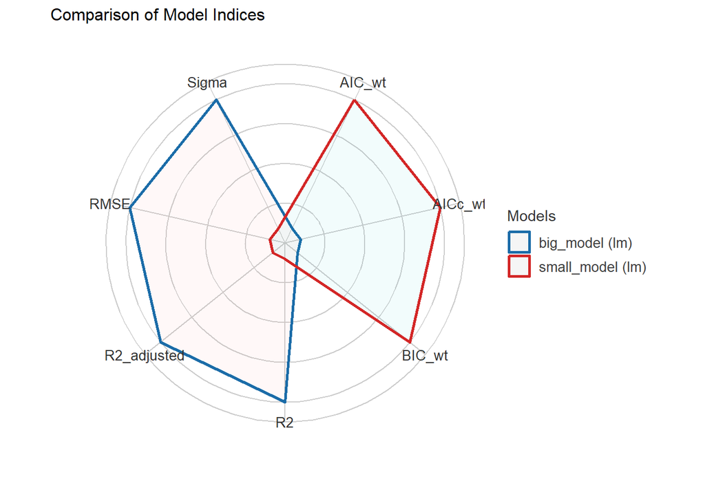

```r
plot(compare_performance(big_model, small_model))
```

At this stage, the models are very comparable to each other with very similar performance and `check_model` results. I think it is hard to make a decision which is better at this stage, but I think the big model is my current pick as it is better or tied with the small model on all non-weighted performance measures.

# 10 Model Validation

## 10.1 Calculating Prediction Errors

```r
aug_big <- augment(big_model, newdata = study2_test) |>
  mutate(mod_name = "big",
         sleep_pred = .fitted,
         sleep_error = sleep - sleep_pred)

aug_small <- augment(small_model, newdata = study2_test) |>
  mutate(mod_name = "small",
         sleep_pred = .fitted,
         sleep_error = sleep - sleep_pred)

test_aug <- bind_rows(aug_big, aug_small) |>
  relocate(seqn, mod_name, sleep, everything()) |>
  arrange(seqn, mod_name)

test_aug |> select(seqn, mod_name, sleep, sleep_pred, sleep_error, .fitted, .resid) |>
  head() |> gt() |> fmt_number(decimals = 4, drop_trailing_zeros = TRUE)
```

| seqn | mod_name | sleep | sleep_pred | sleep_error | .fitted | .resid |
| --- | --- | --- | --- | --- | --- | --- |
| 130379 | big | 9 | 7.638 | 1.362 | 7.638 | 1.362 |
| 130379 | small | 9 | 7.6495 | 1.3505 | 7.6495 | 1.3505 |
| 130386 | big | 7.5 | 7.585 | −0.085 | 7.585 | −0.085 |
| 130386 | small | 7.5 | 7.5926 | −0.0926 | 7.5926 | −0.0926 |
| 130389 | big | 8 | 7.6739 | 0.3261 | 7.6739 | 0.3261 |
| 130389 | small | 8 | 7.6495 | 0.3505 | 7.6495 | 0.3505 |

Here we use the `augment` function to create two new variable: `sleep_pred` which is the value of `sleep` for that subject predicted by our model and `sleep_error` which is the difference between `sleep` and `sleep_pred`.

## 10.2 Visualizing the Predictions

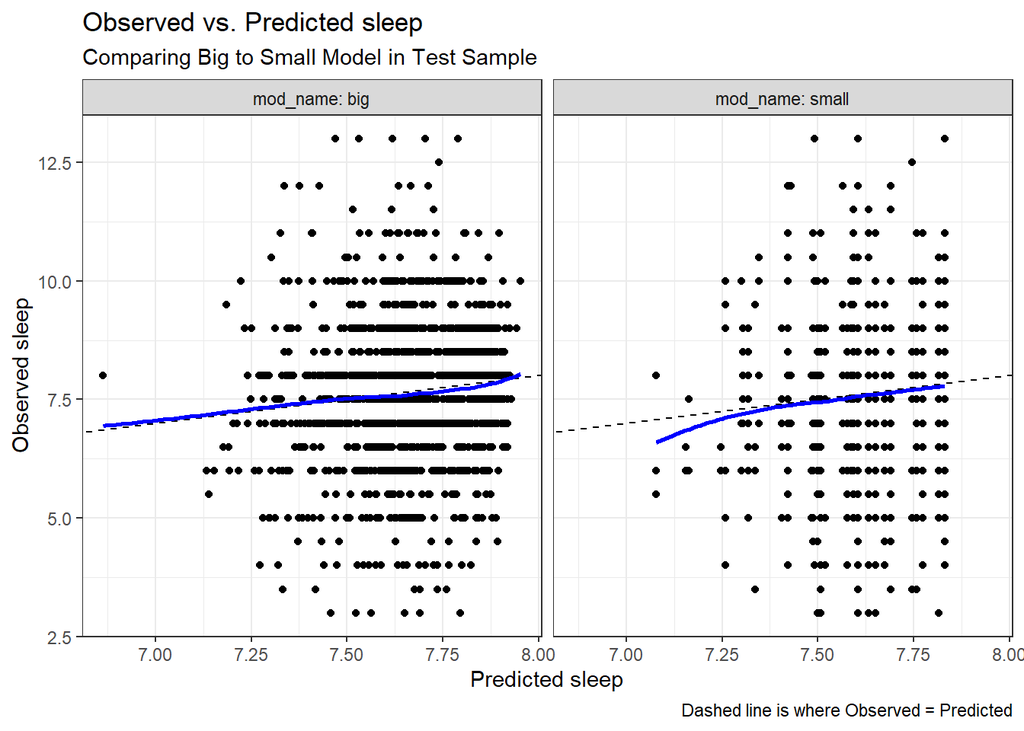

```r
ggplot(test_aug, aes(x = sleep_pred, y = sleep)) +
  geom_point() +
  geom_abline(slope = 1, intercept = 0, lty = "dashed") +
  geom_smooth(method = "loess", col = "blue", se = FALSE, formula = y ~ x) +
  facet_wrap( ~ mod_name, labeller = "label_both") +
  labs(x = "Predicted sleep",
       y = "Observed sleep",
       title = "Observed vs. Predicted sleep",
       subtitle = "Comparing Big to Small Model in Test Sample",
       caption = "Dashed line is where Observed = Predicted")
```

Here it looks like the big model adheres to the dashed line better than the small model, but it is not that big of a difference, so the models are making fairly similar errors. The big model also has a larger range of predicted values.

## 10.3 Summarizing the Errors

```r
test_summary <- test_aug |>
  group_by(mod_name) |>
  summarize(MAPE = mean(abs(sleep_error)),
            Max_APE = max(abs(sleep_error)),
            RMSPE = sqrt(mean(sleep_error^2)),
            R2_val = cor(sleep, sleep_pred)^2)

test_summary  |>
  gt() |> fmt_number(decimals = 4)
```

| mod_name | MAPE | Max_APE | RMSPE | R2_val |
| --- | --- | --- | --- | --- |
| big | 1.0874 | 5.5301 | 1.4540 | 0.0081 |
| small | 1.0874 | 5.5083 | 1.4524 | 0.0099 |

```r
temp1 <- aug_big |>
  filter(abs(sleep_error) == max(abs(sleep_error)))

temp2 <- aug_small |>
  filter(abs(sleep_error) == max(abs(sleep_error)))

bind_rows(temp1, temp2) |> select(seqn, mod_name, sleep, sleep_pred, sleep_error, .fitted, .resid) |>
  gt() |> fmt_number(decimals = 4, drop_trailing_zeros = TRUE)
```

| seqn | mod_name | sleep | sleep_pred | sleep_error | .fitted | .resid |
| --- | --- | --- | --- | --- | --- | --- |
| 133388 | big | 13 | 7.4699 | 5.5301 | 7.4699 | 5.5301 |
| 133388 | small | 13 | 7.4917 | 5.5083 | 7.4917 | 5.5083 |
| 133694 | small | 13 | 7.4917 | 5.5083 | 7.4917 | 5.5083 |

Looking at the maximum absolute value of error for the models, it looks like both models struggled to predict `sleep` values close to the maximum, which is not surprising considering how many values were initially considered outliers.

## 10.4 Comparing the Models

Before I was fairly unconvinced by either model, but now the small model stands out to me. Both models still have very similar performance, but the smaller model’s validated R<sup>2</sup> value stood out to me, since it was a good bit higher than the big model, even though the small model uses far less variables. As such, I think the small model is the better pick, as it has similar or better performance compared to the big model in all our tests, while only using 3 predictors.